# WeRateDogs Twitter Data Analysis Report

[figure not shown]

As suggested by the above image WeRateDogs is a Twitter account that rates people's dogs with a humorous comment about the dog. WeRateDogs asks people to send photos of their dogs, then tweets selected photos with a rating and a humorous comment. Dogs are rated on a scale of one to ten, but are invariably given ratings in excess of the maximum, such as "13/10".

For the data wrangling project from Udacity Data Analyst Nanodegree Program, I had to wrangle and analysis the twitter data from the twitter account [@dog_rates](https://twitter.com/dog_rates) also know as WeRateDogs. Through this project the learners are given a chance to go through the whole data analysis process, from gathering the data to cleaning it and later analyzing, and visualizing trends from the data.

## Data Wrangling

So Data Wrangling, as defined in [Wikipedia](https://en.wikipedia.org/wiki/Data_wrangling) is the process of transforming and mapping data from one "raw" data form into another format with the intent of making it more appropriate and valuable for a variety of downstream purposes such as analytics.

This whole process of transforming data in order to make it more valuable for analysis can be divided into 3 major steps:-

- Data Gathering (*Collecting data from various sources like flat files, web scraping, APIs, etc*)
- Data Assessing (*Gaining an initial understanding of data in order to evaluate the data in terms of its quality and tidiness*)
- Data Cleaning (*Correcting the identified quality and tidiness issues and getting rid of corrupt or inaccurate records*)

### Data Gathering

Data was collected from three different sources:-

- A csv file was provided by Udacity. This file comprised of data from the tweets posted by WeRateDogs twitter account. It contained basic tweet data (tweet ID, timestamp, text, etc.) for all 5000+ of the tweets posted by WeRateDogs as they stood on August 1, 2017.
- Another file was downloaded by a given link which was also provided by Udacity. This filw was downloaded programmatically using Python's [Request](https://2.python-requests.org//en/master/) library. It contained all the image predictions of what breed of dog (or other object, animal, etc.) is present in each tweet according to a neural network.
- The last file was gathered by web scrapping the Twitter account of WeRateDogs with help of Twitter's API using Python's [Tweepy](http://www.tweepy.org) library . The tweets were identified by the tweet ids from the csv file already provided.

### Data Assessing

After gathering the data from different sources I did preliminary assessment of the data by both visual and programmatic assessment. Since three there was data from three different sources in three different formats, the data had to be both dirty (the data has problems with its content) and messy (the structure of the data is not proper). As a result of my assessment I managed to find around 15 issues varying across all the three datasets. Then I had to categorize these issues into two categories - **Quality (dirty data) and Tidiness (messy data)**.

### Data Cleaning

So after the assessment of the data it was time to actually address those issues detected,i.e. cleaning the data. The issues I found in the previous step were mostly very common issues with data which every Data Analyst has to deal with while wrangling, such as missing values, bad data types, wrong entries and other structural issues such as dog stages consisting of four different columns which can be fit into one single column and the different number of records within the three data files including duplication and retweets which had to be removed. All these issues were addressed programmatically using Python's Pandas and Numpy packages.

## Data Analysis and Visualization

Finally after cleaning all the data I was ready to do some analysis on the clean and tidy data. I was left with two clean and tidy data sets, one was a master tweet data and another was tweet image prediction data. The analysis I did was a descriptive one and not inferential.

The approach I followed was to first ask some questions and then dive into analysis of answering them using the data I had. Even though Data assessment is done before analyzing it, in my case analyzing the data revealed many insights about the data which were missed in the assessment phase.

For example, the image prediction data predicted if the image posted along with the tweet was of a dog or not. If it was a dog then it also predicted it's breed along with a confidence percentage of how confident the algorithm is in its prediction. As I cleaned the data I decided to add the breed of the dog to every tweet data in the master dataset by extracting the information from the image prediction dataset. For more accuracy I decided to filter the tweets where the model predicted that the image was of a dog and that it had more than 95% confidence percentage that the prediction was right.

But later during analysis I discovered that for some tweets the model actually failed to detect the dog in the image and hence recorded wrong predictions. The below image was predicted by the model as a "dishwasher" and the dog was totally overlooked (*He is such a good boi! How can you overlook him?*)

[figure not shown]

Again a similar example...

[figure not shown]

For the above image the model predicted a "jigsaw_puzzle" with a 100% confidence percentage which is actually correct. But it failed to detect the dog in it which lead to wrong data.

Moving on to the questions answered in this analysis.

**Which dog stage lead to a high rating score?**

For these I simply had to group the records in the master dataset according to their stages and then calculate the mean ratings for the dogs in each stage group.

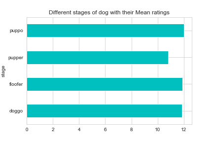

So, it was observed that there is not much significant difference between the Mean ratings for each stage of a dog, but we can conclude that 'puppo' is slightly more popular than the rest.

*Let's explore how does affects a rating score affect the popularity of a tweet?*

**Relation between rating score and the mean number of retweets for a specific rating.**

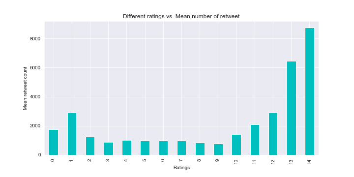

As can be seen from the above visualization, the number of retweets increases drastically for the high rated dogs.

**Relation between rating score and the mean favorite count for a specific rating.**

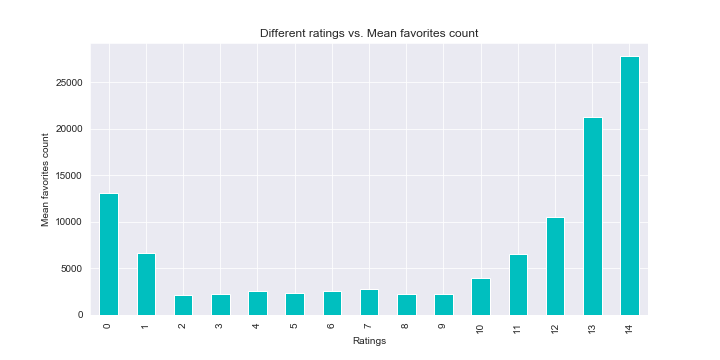

The favorites count also increases drastically for the higher rated dogs.

Hence it can be concluded that both number of retweets and favorites count increases drastically if a tweet has a high rating score.

*Now coming to more general questions that can be answered from our dataset...*

**What is the most common used source for publishing tweets by WeRateDogs?**

| source | count |
| --- | --- |
| Twitter for iPhone | 1958 |
| Vine - Make a Scene | 89 |
| Twitter Web Client | 30 |
| TweetDeck | 10 |

Looks like WeRateDogs uses iPhone the most for posting tweets.

**What are the top 5 most common breed of dog among all the tweets.**

| breed | count |
| --- | --- |
| pug | 20 |
| pembroke | 19 |
| samoyed | 18 |
| golden_retriever | 15 |
| pomeranian | 13 |

Even though I was expecting 'golden retriever' to be the most common breed, it seems like the data along with the prediction model suggests 'pug' is the most common breed along with 'pembroke', 'samoyed', 'golden retriever' and 'pomeranian'.

**What are the top 5 most common names of dogs**

| name | count |
| --- | --- |
| Lucy | 11 |
| Charlie | 10 |
| Cooper | 10 |
| Oliver | 10 |
| Penny | 9 |

Lucy, Charlie, Cooper, Oliver and Pennny are the most popular names among the dogs tweeted by WeRateDogs.

*So after asking all the top five questions let's dive into some trend analysis...*

**Trend for number of tweets over the years.**

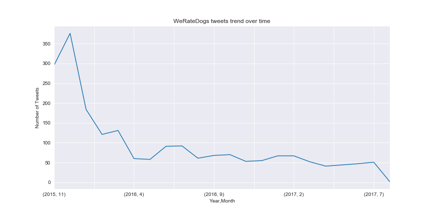

The trend of tweets over time shows that the number of tweets posted by WeRateDogs decreases significantly over time with the number of tweets being highest in the year 2015 to its lowest in the year 2017.

**Trend of retweet and favorites count over time**

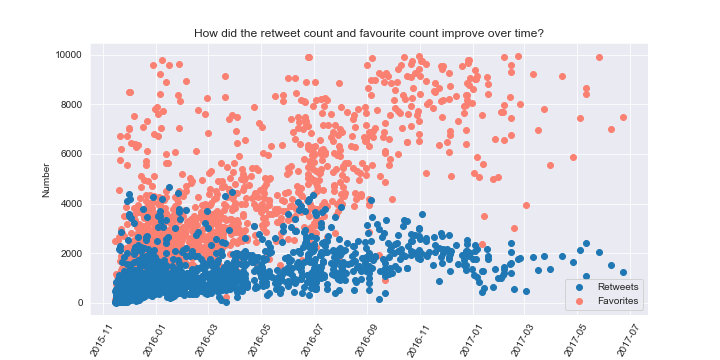

It can be seen that in early years(from the year 2015), the number of tweets posted by WeRateDogs is significantly high than that of the later years(since the end of 2016) and the retweet count and favorite count are both quite similar in number. After 2016, the number of tweets become much lesser, but the the number of the favourite counts become much higher which show that WeRateDogs eventually started posting less number of tweets as their popularity grew over time. Another trend noticed is that favourite counts seem to increase drastically whereas the retweet counts kind of remain constant being less than 5000 for the entire duration.

## Conclusion

This project involved the whole process of Data Wrangling along with drawing insights from the wrangled data by analyzing different metric relations with the help of visualizations. Also, it was more of a iterative process where one has the liberty of going to and fro the process of Data Gathering, Assessing and Cleaning in order to shape and formulated the data in the way one wants it to be for analyzing it. This project covered almost most of the operations a Data Analyst probably does on a daily basis in his/her job. This was a fun project and I really enjoyed going through the whole process of data wrangling and analysis.